# FUNWAVE-TVD beach_2d_radiation diagnostic plots

2026-09-11 03:00 UTC

## Provenance and input data

This is an R translation of the MATLAB files placed in `reference/`: `plot_frc_brk.m`, `plot_balance.m` and `plot_vertical_profile.m`, from the FUNWAVE-TVD `beach_2d_radiation` example. It uses base R for plotting and `terra` to preserve the spatial-grid orientation.

The report reads the latest workflow’s `results/` directory when available; otherwise it uses the included `example_results/` files. The example files are the 30-second GitHub Actions test output and are not intended as a physical forecast. The workflow now runs a 300-second diagnostic case, which passes the 180-second steady-state threshold and generates the averaged radiation terms.

```r
meta_path <- file.path(data_dir, "run-metadata.json")
if (file.exists(meta_path)) {
  cat(paste(readLines(meta_path), collapse = "\n"))
}
```

```
## {
##   "started_at_utc": "2026-09-11T02:41:28Z",
##   "finished_at_utc": "2026-09-11T02:42:49Z",
##   "model": "FUNWAVE-TVD",
##   "test_case": "beach_2d_radiation (300 s diagnostic run)",
##   "mpi_processes": 2,
##   "result_files": [
##     "Ax_00000",
##     "Ax_00001",
##     "Ax_00002",
##     "Ax_00003",
##     "Ax_00004",
##     "Ay_00000",
##     "Ay_00001",
##     "Ay_00002",
##     "Ay_00003",
##     "Ay_00004",
##     "BrkDissX_00001",
##     "BrkDissY_00001",
##     "BrkSrcX_00000",
##     "BrkSrcX_00001",
##     "BrkSrcX_00002",
##     "BrkSrcX_00003",
##     "BrkSrcX_00004",
##     "BrkSrcY_00000",
##     "BrkSrcY_00001",
##     "BrkSrcY_00002",
##     "BrkSrcY_00003",
##     "BrkSrcY_00004",
##     "Bx_00000",
##     "Bx_00001",
##     "Bx_00002",
##     "Bx_00003",
##     "Bx_00004",
##     "By_00000",
##     "By_00001",
##     "By_00002",
##     "By_00003",
##     "By_00004",
##     "DxSxx_00001",
```

[output cut: 42 more lines]

```
##     "u_00001",
##     "u_00002",
##     "u_00003",
##     "u_00004",
##     "ulagm_00001",
##     "umean_00001",
##     "v_00000",
##     "v_00001",
##     "v_00002",
##     "v_00003",
##     "v_00004",
##     "vlagm_00001",
##     "vmean_00001"
##   ]
## }
```

## Instantaneous elevation, breaking and friction

This reproduces the three-panel layout in `plot_frc_brk.m`. The source MATLAB example uses output number 21; this report detects and uses the latest available instantaneous output (00004).

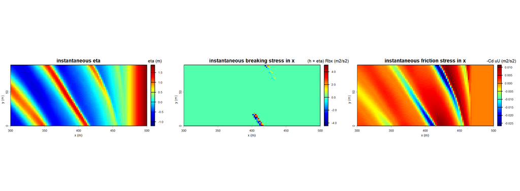

```r
old_par <- par(no.readonly = TRUE)
on.exit(par(old_par), add = TRUE)
layout(matrix(1:3, nrow = 1))
plot_field(eta, "instantaneous eta", "eta (m)")

if (is.null(brk_x)) {
  plot.new(); title("breaking stress in x")
  text(0.5, 0.5, "BrkSrcX output is not available")
} else {
  plot_field(brk_x, "instantaneous breaking stress in x", "(h + eta) Rbx (m2/s2)")
}

if (is.null(frc_x)) {
  plot.new(); title("friction stress in x")
  text(0.5, 0.5, "FrcInsX output is not available")
} else {
  plot_field(frc_x, "instantaneous friction stress in x", "-Cd uU (m2/s2)")
}
```

## Averaged momentum-balance terms

`plot_balance.m` and the averaged lower panel in `plot_frc_brk.m` require `PgrdX`, `FRCX`, `DxSxx`, `DySxy`, `DxUUH`, `DyUVH`, `PgrdY`, `FRCY`, `DySyy`, `DxSxy`, `DyVVH`, `DxUVH` and `BrkDissX`. The compact test case does not request these fields, so the section activates automatically only when all required outputs are present.

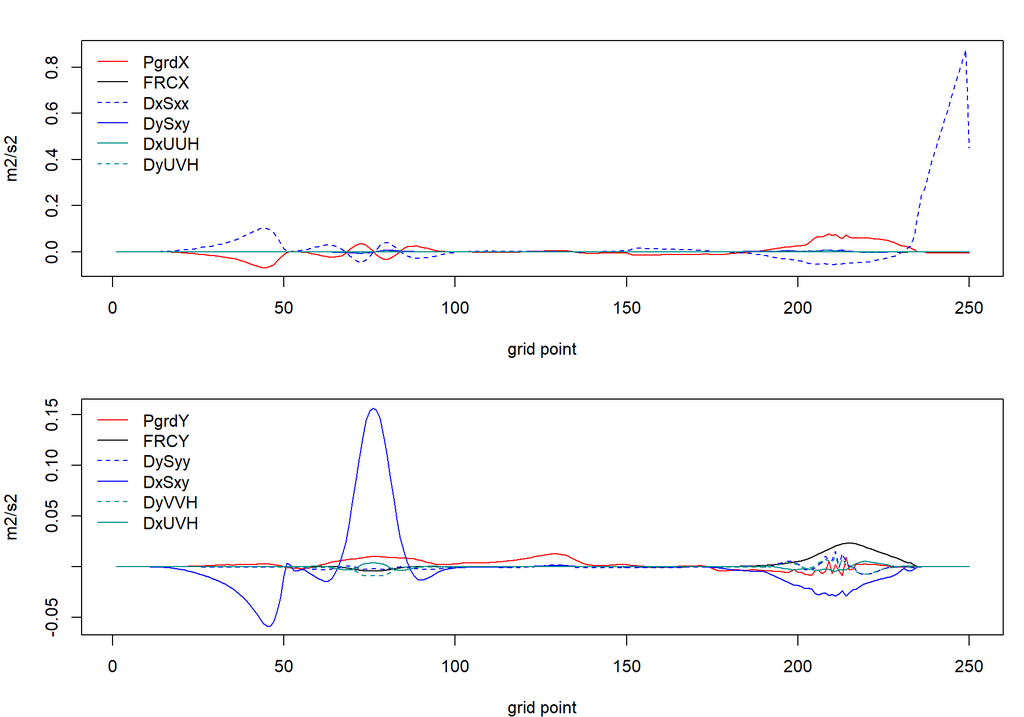

```r
required_x <- c("PgrdX", "FRCX", "DxSxx", "DySxy", "DxUUH", "DyUVH")
required_y <- c("PgrdY", "FRCY", "DySyy", "DxSxy", "DyVVH", "DxUVH")
balance_numbers <- sub("^PgrdX_", "", list.files(data_dir, pattern = "^PgrdX_[0-9]{5}$"))
balance_number <- if (length(balance_numbers)) tail(sort(balance_numbers), 1) else NA_character_
available_balance <- !is.na(balance_number) && all(vapply(c(required_x, required_y), function(nm)
  file.exists(field_path(nm, balance_number)), logical(1)))

if (!available_balance) {
  cat("Averaged momentum-balance fields were not written by this run.\n")
} else {
  ny <- 25
  x_terms <- lapply(required_x, read_field, number = balance_number)
  names(x_terms) <- required_x
  y_terms <- lapply(required_y, read_field, number = balance_number)
  names(y_terms) <- required_y
  old_par <- par(no.readonly = TRUE); on.exit(par(old_par), add = TRUE)
  par(mfrow = c(2, 1), mar = c(4, 4, 2, 1))
  matplot(vapply(x_terms, function(z) z[ny, ], numeric(ncol(eta))), type = "l",
          lty = c(1, 1, 2, 1, 1, 2), col = c("red", "black", "blue", "blue", "cyan4", "cyan4"),
          xlab = "grid point", ylab = "m2/s2")
  legend("topleft", legend = names(x_terms), lty = c(1, 1, 2, 1, 1, 2),
         col = c("red", "black", "blue", "blue", "cyan4", "cyan4"), bty = "n")
  matplot(vapply(y_terms, function(z) z[ny, ], numeric(ncol(eta))), type = "l",
          lty = c(1, 1, 2, 1, 2, 1), col = c("red", "black", "blue", "blue", "cyan4", "cyan4"),
          xlab = "grid point", ylab = "m2/s2")
  legend("topleft", legend = names(y_terms), lty = c(1, 1, 2, 1, 2, 1),
         col = c("red", "black", "blue", "blue", "cyan4", "cyan4"), bty = "n")
}
```

## Vertical velocity reconstruction

The MATLAB `plot_vertical_profile.m` reconstructs vertical profiles using `dep.out`, `Ax`, `Ay`, `Bx` and `By`. It performs the calculation but does not actually issue a plotting command. The same reconstruction can be made in R when these diagnostic fields are enabled in FUNWAVE; they are not in the compact test output.

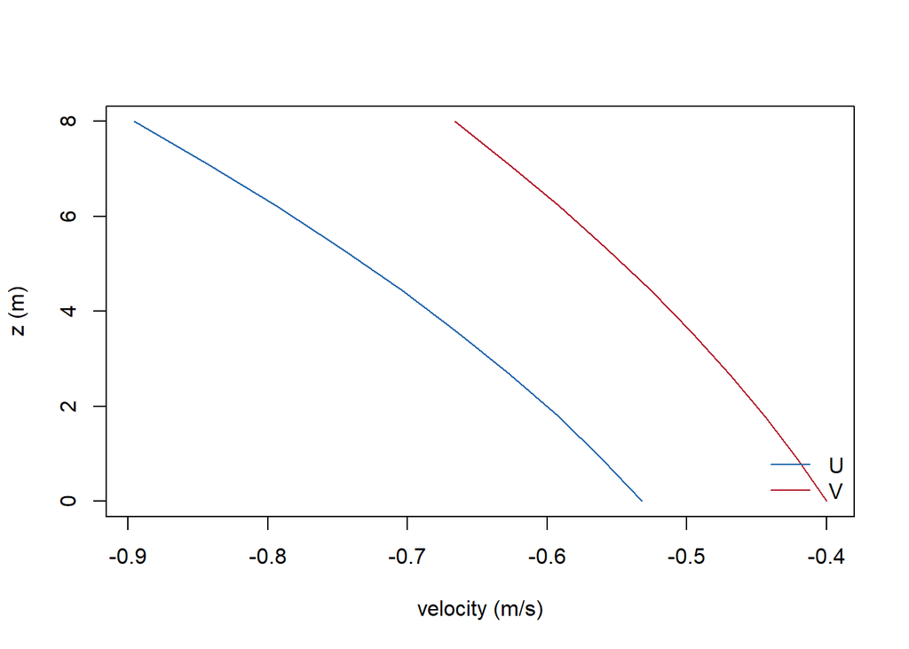

```r
vertical_fields <- c("dep.out", "Ax", "Ay", "Bx", "By", "u", "v", "eta")
has_vertical <- file.exists(file.path(data_dir, "dep.out")) &&
  all(vapply(vertical_fields[-1], function(nm) file.exists(field_path(nm)), logical(1)))

if (!has_vertical) {
  cat("Vertical-profile diagnostics were not written by this run.\n")
} else {
  dep <- as.matrix(utils::read.table(file.path(data_dir, "dep.out"), header = FALSE))
  ax <- read_field("Ax"); ay <- read_field("Ay")
  bx <- read_field("Bx"); by <- read_field("By")
  u <- read_field("u"); v <- read_field("v")
  z_levels <- seq(0, -1, length.out = 10)
  iy <- ceiling(nrow(dep) / 2); ix <- ceiling(ncol(dep) / 2)
  z <- -dep[iy, ix] * z_levels
  za <- -0.5528 * dep[iy, ix] + 0.4472 * eta[iy, ix]
  U <- u[iy, ix] + (za - z) * ax[iy, ix] + 0.5 * (za^2 - z^2) * bx[iy, ix]
  V <- v[iy, ix] + (za - z) * ay[iy, ix] + 0.5 * (za^2 - z^2) * by[iy, ix]
  matplot(cbind(U, V), z, type = "l", lty = 1, col = c("#2166AC", "#B2182B"),
          xlab = "velocity (m/s)", ylab = "z (m)")
  legend("bottomright", c("U", "V"), col = c("#2166AC", "#B2182B"), lty = 1, bty = "n")
}
```